# Spatial Autocorrelation in Ecological Data

Vojta Barták

2023-06-26

## Required packages

```r
library(tidyverse) # General metapackage for manipuating and visualizing data
library(sf)        # Vector spatial data manipulation and analysis
library(stars)     # Raster spatial data manipulation and analysis (compatible with sf)
library(tmap)      # Spatial data display
library(spdep)     # Areal data analysis, Moran's I, spatial dependence weighting
library(pgirmess)  # Function correlog
library(gstat)     # Geostatistics
#library(geoR)
```

## Loading and visualizing the data

Let’s load the data on bird species richness in the Krkonoše National Park (KRNAP). The survey was done in mapping quadrats of 1.5 km^2 size. The function `st_as_sf` from the `sf` package is used to convert the dataframe into a Single Feature object, i.e. the object with vector spatial data.

```r
krnap <- read.table("data/krnap_richness.csv", sep=",", header=T) %>%
  st_as_sf(coords=c("X", "Y"), crs=5514, remove=F)
dtm <- read_stars("data/dtm_CR_1000.tif")
```

`tmap` package provides functions to display spatial data and to efficiently produce nice thematic maps. It has two modes. In the default “plot” mode, a static map is produced. In the “view” mode, the map is rendered as an interactive web map on the Open Street Maps basemap (it uses the leaflet library).

The function `qtm` produces a “Quick Thematic Map” from the input data with a minimal code. It is useful for the first quick look at the data.

```r
tmap_mode("view")
qtm(krnap)
```

[interactive chart not shown]

For more tuned display, you first call the `tm_shape` specifying the spatial data to be displayed, and then follow (using the ggplot-like `+` notation) with some of the functions specifying what kind of symbols should be used for the layer, what attribute variable should be displayed, and possibly other layer details.

```r
tm_shape(krnap) +
  tm_dots("richness")
```

[interactive chart not shown]

You can combine multiple layers by chaining them with `+`, each layer beginning with a new `tm_shape` call. The `tm_layout` can be used to control the layout components, like the legend.

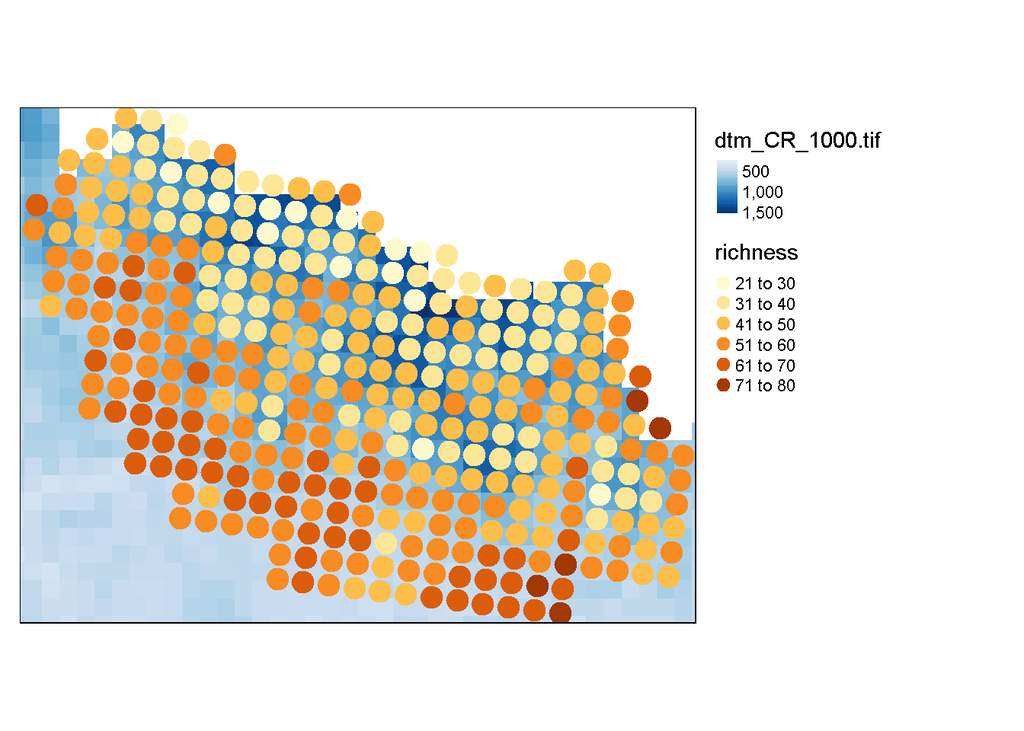

```r
tmap_mode("plot")
tm_shape(dtm) +
  tm_raster(style="cont", palette="Blues") +
  tm_shape(krnap, is.master = T) +
  tm_dots("richness", size=1) +
  tm_layout(legend.outside = T)
```

## Measuring and testing global spatial autocorrelation

Although our data represent aggregated information about the underlying continuous phenomenon (i.e., the bird species richness), to compute the Moran’s I, we need to treat them as discrete entities and define their interconnectivity relations (spatial neighbors) and spatial dependence structure (spatial weights). (This is not true for estimating the variogram, as you will see later).

### Spatial neighbors

The first step is to define for each observation, what observations are considered its spatial neoghbors, i.e. having some spatial relationship with it. The function `dnearneigh` defines the neighbors based on their euclidean distance. In the code below, the observation lying between 1 and 2 km from the target observation are considered its neighbors. The resulting network is then plotted.

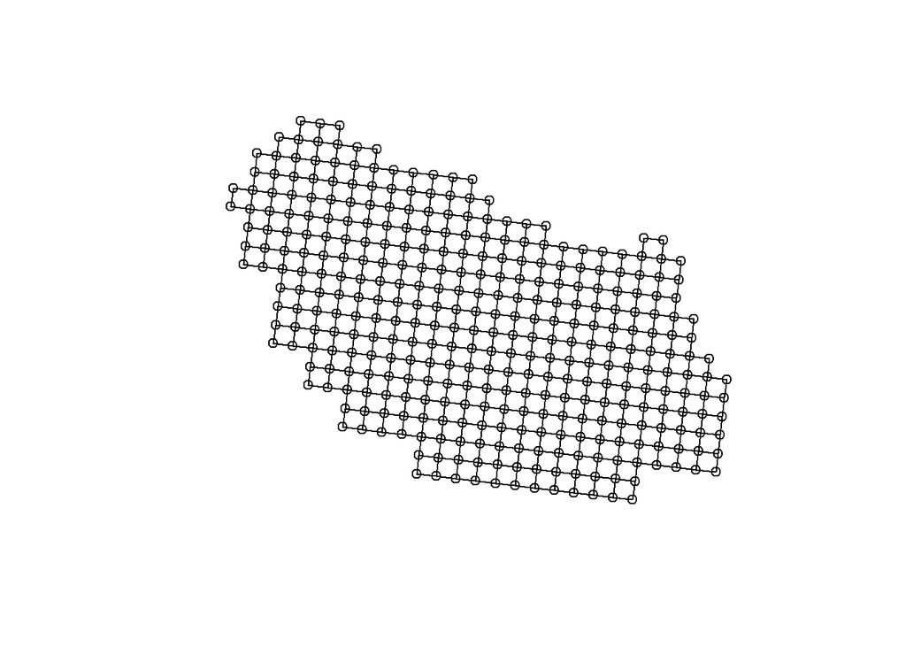

```r
neibs <- dnearneigh(st_coordinates(krnap), d1=1000, d2=2000)
plot(neibs, coords=st_coordinates(krnap))
```

-> Try different `d1` and `d2` settings and plot the resulting network.

### Spatial weights

The next step is to define a weight for each neigbour connection, reflecting the strenght of the corresponding spatial relationship. In our case (i.e., continuous data), the best choice is to assign a constant weight of 1 to all connections, because the only reasonable assumption about the spatial dependence is that it decreases with distance, and the role of distance is alrealy incorporated in the definition of neighbors. (Later we will show how the weights could be created directly based on distances.)

The function `nb2listw` converts the neighbors into a list of weights. There are multiple weighting styles, differing in the way how the weights are standardized. the style “B” simply keeps the weights as they are. In our case, each connection has a weight of 1. Another style could be “W”, which standardize the weights so that all the weights of each observation sum up to unity. This style is sometimes useful, as we will see very soon. (Other styles are possible, which are not explained here.)

```r
weights <- nb2listw(neibs, style="B")
summary(weights)
```

```
## Characteristics of weights list object:
## Neighbour list object:
## Number of regions: 348
## Number of nonzero links: 1298
## Percentage nonzero weights: 1.071806
## Average number of links: 3.729885
## Link number distribution:
##
##   2   3   4
##  23  48 277
## 23 least connected regions:
## 27 60 62 96 98 165 167 201 202 204 238 243 250 251 252 253 254 260 301 327 334 346 348 with 2 links
## 277 most connected regions:
## 1 2 4 5 6 7 8 9 10 11 12 13 14 15 16 17 18 19 20 21 22 23 25 26 30 31 32 33 34 35 36 37 38 39 40 41 42 43 44 45 46 47 48 49 50 51 52 53 54 55 56 57 58 59 63 64 65 66 67 68 69 70 71 72 73 74 75 76 77 78 79 80 81 82 83 84 85 86 87 88 89 90 91 92 93 94 95 100 101 102 103 104 105 106 107 108 109 110 …
##
## Weights style: B
## Weights constants summary:
##     n     nn   S0   S1    S2
## B 348 121104 1298 2596 19824
```

```r
summary(unlist(weights$weights))
```

```
##    Min. 1st Qu.  Median    Mean 3rd Qu.    Max.
##       1       1       1       1       1       1
```

### Moran scatterplot

One possible way to look at the spatial autocorrelation is the so called Moran scatterplot. It is a graphical comparison of the species richness at a site and the weighted sum of the species richness at its neighbors. However, the weighting style makes a difference here. With the “B” style, the weights are all same and so the weighted sum will be smaller for the sites with less neighbors. This is typical for the sites at the boundary of the study area. With the weighting style “W”, however, the weights of each site are standardized to unit sum, and so each weighted sum of neighboring values is actually a weighted average. This makes much more sense in this context and overcomes the edge effect we just mentioned. For this reason, we generate the weights again inside the `moran.plot` call, using the “W” style.

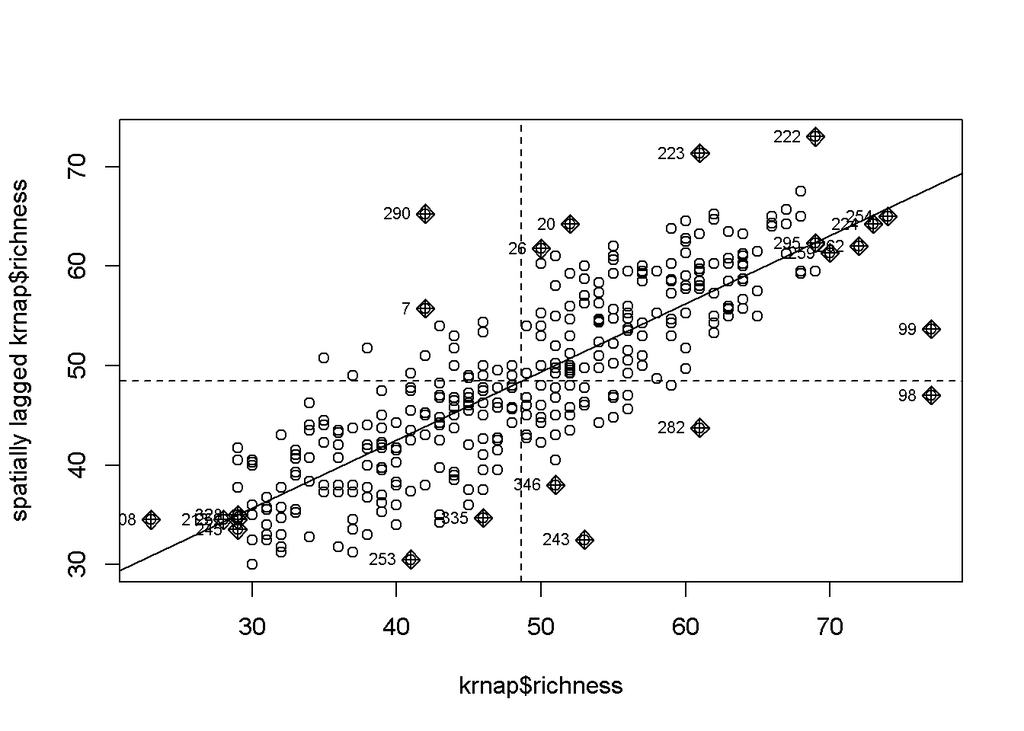

```r
mp <- moran.plot(krnap$richness, listw = nb2listw(neibs, style="W"))
```

As you can see, there is clear spatial dependence at the scale of the neighbors. The positive slope of the regression line in the plot suggests that the species richness is obviously correlated with the species richness at the neighboring sites.

### Global Moran’s I

Having the neighbors and the corresponding weights defined, we can quantify the spatial autocorrelation by calculating the Moran’s I index. It can be also tested by comparing its value with its expected value under the null hypothesis of no spatial autocorrelation. (The expected value is not exactly 0, as one would expect, but it is -1/(n-1), where n is the total number of observations.) If we divide the difference between the observed and expected Moran’s I by the square root of it’s variance, we obtain a standard deviate that can be compared with the standard normal distribution to obtain a p value.

The test is done using the `moran.test` function from the `spdep` package.

```r
moran.test(krnap$richness, weights)
```

```
##
##  Moran I test under randomisation
##
## data:  krnap$richness
## weights: weights
##
## Moran I statistic standard deviate = 17.327, p-value < 2.2e-16
## alternative hypothesis: greater
## sample estimates:
## Moran I statistic       Expectation          Variance
##       0.674088668      -0.002881844       0.001526551
```

Although the test is based on the Normal approximation, which usually holds unless the sample is not very small, by default the `moran.test` function estimates the variance using a correction for a kurtosis possibly differing from that of the normal distribution. To use the pure normal approximation, we can set `randomization = F` (try it!).

If we prefer using the Geary’s C instead od Moran’s I, we can call `greary.test` with the same options.

-> Try to test Geary’s C.

An alternative way to perform the Moran test is via the function `lm.morantest`, which tests the autocorrelation in residuals of a (generalized) linear model. Using an intercept-only model, we obtain the same test as before:

```r
lm.morantest(lm(richness~1, krnap), weights)
```

```
##
##  Global Moran I for regression residuals
##
## data:
## model: lm(formula = richness ~ 1, data = krnap)
## weights: weights
##
## Moran I statistic standard deviate = 17.344, p-value < 2.2e-16
## alternative hypothesis: greater
## sample estimates:
## Observed Moran I      Expectation         Variance
##      0.674088668     -0.002881844      0.001523500
```

There are two advantages of this approach. First, we can generalize this to models with covariates (we’re gonna do this later). Second, there are versions of the functions providing more robust tests, i.e. without the asymptotic normality assumption. These is `lm.morantest.sad` for the so called “saddlepoint approximantion”, and `lm.morantest.exact` for a combinatorial-based exact test. The latter test goes through all the possible permutations of the values, with the positions of sites kept fixed, each time calculating the Moran’s I, and then comapring the observed values with the distribution of the values from the permutations. This test is generally best, as it has no distributional assuptions. Because it is computationally intensive, however, it can only be used for small to moderate sample sizes.

```r
lm.morantest.exact(lm(richness~1, krnap), weights)
```

```
##
##  Global Moran I statistic with exact p-value
##
## data:
## model:lm(formula = richness ~ 1, data = krnap)
## weights: weights
##
## Exact standard deviate = 6.7495, p-value = 7.419e-12
## alternative hypothesis: greater
## sample estimates:
## [1] 0.6740887
```

In case of larger samples, a Monte Carlo test is available, which is based on the same principle as the exact test, but instead of going through all the permutations, it randomly sample from them:

```r
moran.mc(krnap$richness, weights, nsim=999)
```

```
##
##  Monte-Carlo simulation of Moran I
##
## data:  krnap$richness
## weights: weights
## number of simulations + 1: 1000
##
## statistic = 0.67409, observed rank = 1000, p-value = 0.001
## alternative hypothesis: greater
```

Note the larger p value compared to previous tests. It should be understood that for Monte Carlo test, the lowest possible p value is bounded by the number of simulations. With `nsim = 999`, the lowest possible p value is 0.001, which is exactly what we got. This p value should be then interpreted as the maximum one, i.e. the true p value is less than or equal to 0.001.

-> Try to set the number of simulations to 9999 and see the resulting p value.

The weights can also be defined directly based on distance, i.e. as an inverse distance weights. The function `nbdists` is used first to compute the distances between the neighbors. Then, the `lapply` function is used to invert these distances in a loop. Then the function `nb2listw` is used to convert the neighbors to weights, with the parameter `glist` set to the list of inverse distances.

```r
dst <- nbdists(neibs, st_coordinates(krnap))
idw <- lapply(dst, function(x) 1/x)
dst.weights <- nb2listw(neibs, glist = idw, style="B")
summary(unlist(dst.weights$weights))
```

```
##      Min.   1st Qu.    Median      Mean   3rd Qu.      Max.
## 0.0006787 0.0006802 0.0006818 0.0006995 0.0007191 0.0007192
```

```r
moran.test(krnap$richness, dst.weights)
```

```
##
##  Moran I test under randomisation
##
## data:  krnap$richness
## weights: dst.weights
##
## Moran I statistic standard deviate = 17.323, p-value < 2.2e-16
## alternative hypothesis: greater
## sample estimates:
## Moran I statistic       Expectation          Variance
##       0.674202315      -0.002881844       0.001527739
```

As we see, there is almost no difference in the Moran’s I and the test, which is not suprising given the fact that the neoghbors are already defined based on distance.

## Local spatial autocorrelation

So far, we have investigated the global spatial autocorrelation that summarizes the whole spatial pattern into a single number (i.e., the Moran’s I value). This is actually based on an underlying assumption of stacionarity, i.e. that the nature of the spatial dependence does not vary over the space. With real data, this is not always the case. To investigate local differences in the pattern of spatial dependence, we can decompose the global Moran’s I into its components corresponding to the individual sites. These components are called local Moran’s Is, and for each, a similar test as for the global one can be performed.

```r
loc.mor <- localmoran(krnap$richness, nb2listw(neibs, style = "W"))
head(loc.mor)
```

```
##            Ii          E.Ii       Var.Ii      Z.Ii Pr(z != E(Ii))
## 1 0.003115273 -8.977733e-06 0.0007742836 0.1122783    0.910602731
## 2 0.032471097 -2.781371e-04 0.0239814508 0.2114771    0.832514970
## 3 0.646836789 -9.880173e-04 0.1138349369 1.9200821    0.054847536
## 4 0.051261719 -4.679352e-05 0.0040355492 0.8076777    0.419276136
## 5 0.879303394 -6.499112e-03 0.5568773349 1.1870175    0.235220705
## 6 1.320629731 -2.611872e-03 0.2246742431 2.7916599    0.005243845
```

Because each local Moran’s I is calculated solely based on the few neighbors of a given site, the exact test is much more appropriate in this case.

```r
loc.mor <- localmoran.exact(lm(richness~1, krnap), nb = neibs)
head(as.data.frame(loc.mor))
```

```
##     Local Morans I Stand. dev. (N)     Pr. (N)   Exact SD Pr. (exact)
## 1 1    0.003115273      0.01208089 0.990361081 0.03539696  0.97176321
## 2 2    0.032471097      0.07121669 0.943225295 0.20554155  0.83714904
## 3 3    0.646836789      1.13183653 0.257703168 1.34954528  0.17716189
## 4 4    0.051261719      0.10906944 0.913147413 0.28622713  0.77470417
## 5 5    0.879303394      1.77711708 0.075548979 1.74995426  0.08012621
## 6 6    1.320629731      2.66614643 0.007672627 2.19423047  0.02821884
##      Expectation  Variance    Skewness Kurtosis  Minimum    Maximum oT
## 1 1 -0.002881844 0.2464265 -0.03423579 8.797390 85.87419  -86.87419  E
## 2 2 -0.002881844 0.2464265 -0.03423579 8.797390 85.87419  -86.87419  E
## 3 3 -0.002881844 0.3295211 -0.02960635 8.797194 99.38118 -100.38118  E
## 4 4 -0.002881844 0.2464265 -0.03423579 8.797390 85.87419  -86.87419  E
## 5 5 -0.002881844 0.2464265 -0.03423579 8.797390 85.87419  -86.87419  E
## 6 6 -0.002881844 0.2464265 -0.03423579 8.797390 85.87419  -86.87419  E
```

The local Is and the associated p values can be plotted in a map:

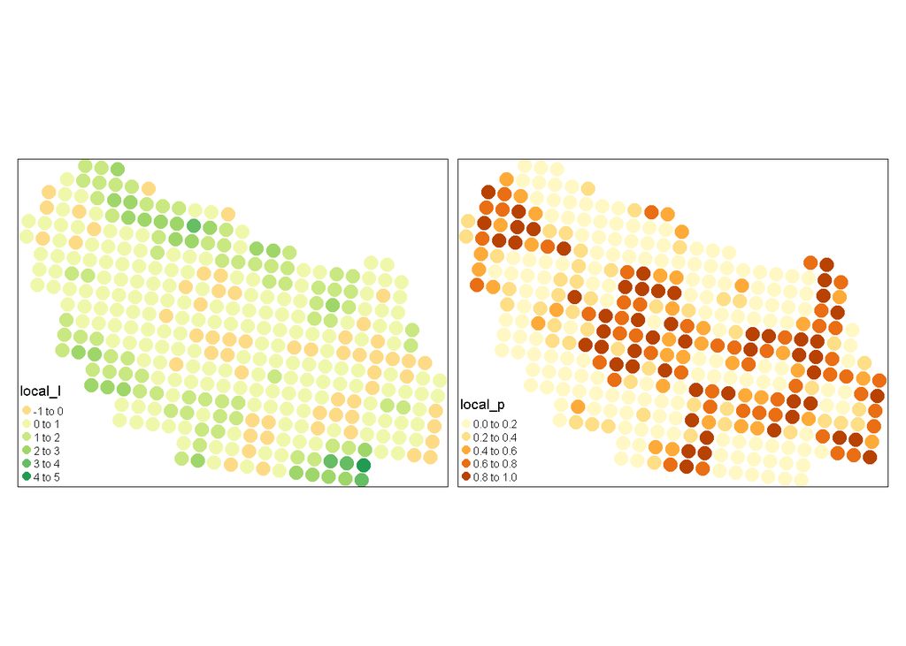

```r
krnap$local_I <- sapply(loc.mor, function(x) x$estimate)
krnap$local_p <- sapply(loc.mor, function(x) x$p.value)
tm_shape(krnap) +
  tm_dots(c("local_I","local_p"), size=1) +
  tm_layout(legend.position = c("LEFT","BOTTOM"))
```

The interpretation is similar as with the global I: high positive values indicate those sites with species richness highly similar to that of its neighbors; high negative values (rarely present) indicate negatively correlated values; and values near zero indicate sites that are independent from their neighborhood. The values, however, are no longer bounded in -1 and 1, and the interpretation of the absolute values is unclear. For this reason, it is also useful to depict the p values: the values near 0 indicate sites that are correlated with their neighborhood, which typically means they have similar richness values. Such areas can be called “clusters”. On the other hand, the p values near 1 indicate site that are independent of their neighborhoods, which often leads to differing richness values and can depict “hotspots”.

It is important to note, however, that the p values should not be taken rigorously as indicators of a “statistical significance”, at least because of the problem of multiple testing. Instead, they provide an exploratory information about the dataset.

In our case, we can roughly identify three zones along the elevational gradient: from a cluster of similar values in the south, through differing values in a kind of transition zone, to another cluster of similar values in higher altitudes at the north.

## Spatial autocorrelation as a function of distance

### Correlogram

So far, we have investigated the spatial autocorrelation in the scale of the neighbors, i.e. whether or not species richness depends on its values at the 1 to 2 km distance. This is usually not enough. Instead, we want to know what is the actual scale of the spatial dependence, and at what distances the autocorrelation does or does not play a role. To achieve this, we can compute the autocorrelation coefficient (like Moran’s I) for multiple distance classes, and plot it against distance. The resulting plot is called correlogram, and it is a very common and efficient exploratory tool.

There are multiple ways how to get the correlogram. The `sp.correlogram` function from the `spdep` package simply computes the Pearson’s correlation coefficient for pairs based on different neighbor orders, i.e. first for the neighbors, then for the neighbors of the neighbors, etc.

```r
sp.cor <- sp.correlogram(neibs, krnap$richness, order=10)
sp.cor
```

```
## Spatial correlogram for krnap$richness
## method: Spatial autocorrelation
##           1           2           3           4           5           6
##  0.82060393  0.76209792  0.68778193  0.61268347  0.56273680  0.46754255
##           7           8           9          10
##  0.35360295  0.22014343  0.05235979 -0.14483543
```

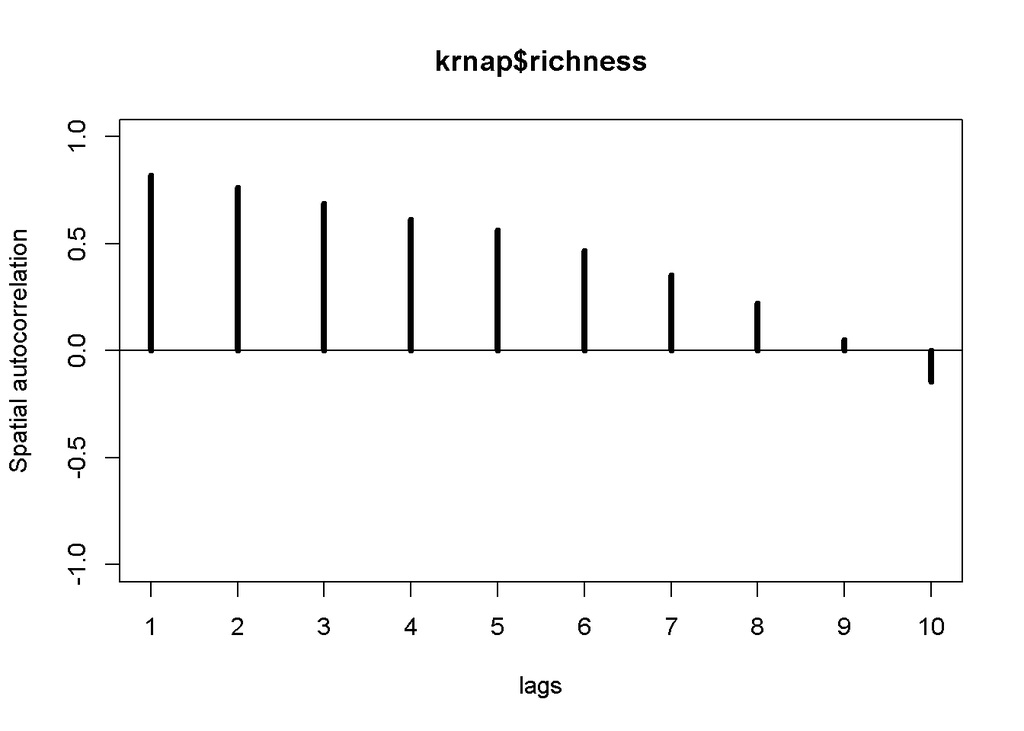

```r
plot(sp.cor)
```

From the resulting plot, we can nicely see how the autocorrelation decreases with distance. The disadvantage of using the Pearson’s correlation coefficient is that there is no distributional theory applicable for its use in the context of autocorrelation. If we want to add a test for each distance level, we again need to use the Moran’s I. This can be done by setting `method = I` (`method = C` would provide Geary’s C values and tests).

```r
sp.cor <- sp.correlogram(neibs, krnap$richness, order=10, method = "I")
sp.cor
```

```
## Spatial correlogram for krnap$richness
## method: Moran's I
##             estimate expectation    variance standard deviate Pr(I) two sided
## 1 (348)   0.68561667 -0.00288184  0.00156530          17.4022       < 2.2e-16
## 2 (348)   0.57189855 -0.00288184  0.00083858          19.8486       < 2.2e-16
## 3 (348)   0.45425613 -0.00288184  0.00059315          18.7700       < 2.2e-16
## 4 (348)   0.34637150 -0.00288184  0.00047210          16.0740       < 2.2e-16
## 5 (348)   0.27547322 -0.00288184  0.00040180          13.8866       < 2.2e-16
## 6 (348)   0.19574801 -0.00288184  0.00035686          10.5146       < 2.2e-16
## 7 (348)   0.12080320 -0.00288184  0.00032712           6.8385           8e-12
## 8 (348)   0.06225413 -0.00288184  0.00030761           3.7138       0.0002042
## 9 (348)   0.01293536 -0.00288184  0.00029510           0.9208       0.3571784
## 10 (348) -0.03359301 -0.00288184  0.00028881          -1.8071       0.0707425
##
## 1 (348)  ***
## 2 (348)  ***
## 3 (348)  ***
## 4 (348)  ***
## 5 (348)  ***
## 6 (348)  ***
## 7 (348)  ***
## 8 (348)  ***
## 9 (348)
## 10 (348) .
## ---
## Signif. codes:  0 '***' 0.001 '**' 0.01 '*' 0.05 '.' 0.1 ' ' 1
```

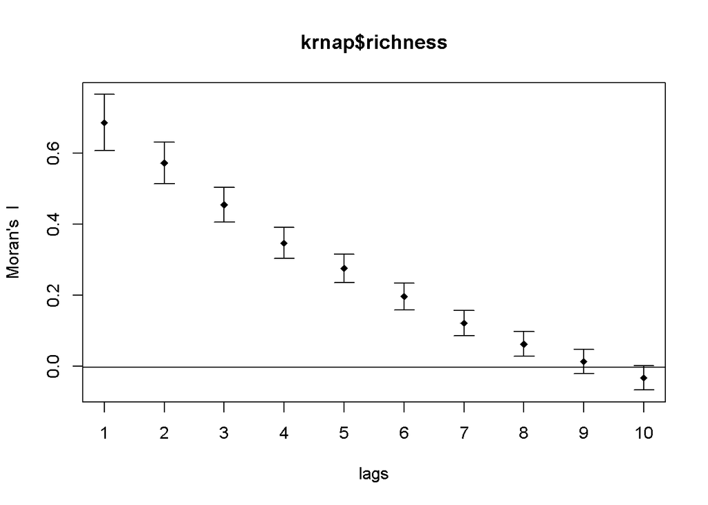

```r
plot(sp.cor)
```

We see that the autocorrelation is significant up to the eighth order, which roughly correspond to the distance of 8 to 9 km. The p values, however, should be adjusted for mutliple testing. This can be done in the `print` method by setting the `p.adj.method`:

```r
print(sp.cor, p.adj.method = "holm")
```

```
## Spatial correlogram for krnap$richness
## method: Moran's I
##             estimate expectation    variance standard deviate Pr(I) two sided
## 1 (348)   0.68561667 -0.00288184  0.00156530          17.4022       < 2.2e-16
## 2 (348)   0.57189855 -0.00288184  0.00083858          19.8486       < 2.2e-16
## 3 (348)   0.45425613 -0.00288184  0.00059315          18.7700       < 2.2e-16
## 4 (348)   0.34637150 -0.00288184  0.00047210          16.0740       < 2.2e-16
## 5 (348)   0.27547322 -0.00288184  0.00040180          13.8866       < 2.2e-16
## 6 (348)   0.19574801 -0.00288184  0.00035686          10.5146       < 2.2e-16
## 7 (348)   0.12080320 -0.00288184  0.00032712           6.8385         3.2e-11
## 8 (348)   0.06225413 -0.00288184  0.00030761           3.7138       0.0006125
## 9 (348)   0.01293536 -0.00288184  0.00029510           0.9208       0.3571784
## 10 (348) -0.03359301 -0.00288184  0.00028881          -1.8071       0.1414851
##
## 1 (348)  ***
## 2 (348)  ***
## 3 (348)  ***
## 4 (348)  ***
## 5 (348)  ***
## 6 (348)  ***
## 7 (348)  ***
## 8 (348)  ***
## 9 (348)
## 10 (348)
## ---
## Signif. codes:  0 '***' 0.001 '**' 0.01 '*' 0.05 '.' 0.1 ' ' 1
```

We see that the general result is unaltered in this case.

A slightly better looking plot is obtained by the `correlog` function from the package `pgirmess`. The major advantage is that there is directly the distance displayed at the x axis. The red points indicate significant values (without, however, any multiple testing adjustments).

```r
sp.cor2 <- correlog(st_coordinates(krnap), krnap$richness, method = "Moran")
sp.cor2
```

```
## Moran I statistic
##       dist.class        coef       p.value     n
##  [1,]   2576.133  0.56211761 4.197965e-215  6098
##  [2,]   4947.583  0.31589704 1.485858e-122 10576
##  [3,]   7319.033  0.13475393  1.705148e-28 12162
##  [4,]   9690.483  0.06826326  1.632452e-09 12936
##  [5,]  12061.932 -0.02007026  9.309945e-01 13654
##  [6,]  14433.382 -0.13825885  1.000000e+00 13938
##  [7,]  16804.832 -0.13588647  1.000000e+00 12144
##  [8,]  19176.282 -0.13385163  1.000000e+00 10296
##  [9,]  21547.731 -0.14001277  1.000000e+00  8128
## [10,]  23919.181 -0.09977560  9.999996e-01  6458
## [11,]  26290.631 -0.07953090  9.997491e-01  5364
## [12,]  28662.081 -0.05674762  9.735862e-01  3632
## [13,]  31033.530 -0.07653042  9.868384e-01  2464
## [14,]  33404.980 -0.14534323  9.998152e-01  1680
## [15,]  35776.430 -0.04203096  6.994438e-01   760
## [16,]  38147.880  0.07293325  1.071872e-01   392
## [17,]  40519.330  0.19294072  4.441254e-02    74
```

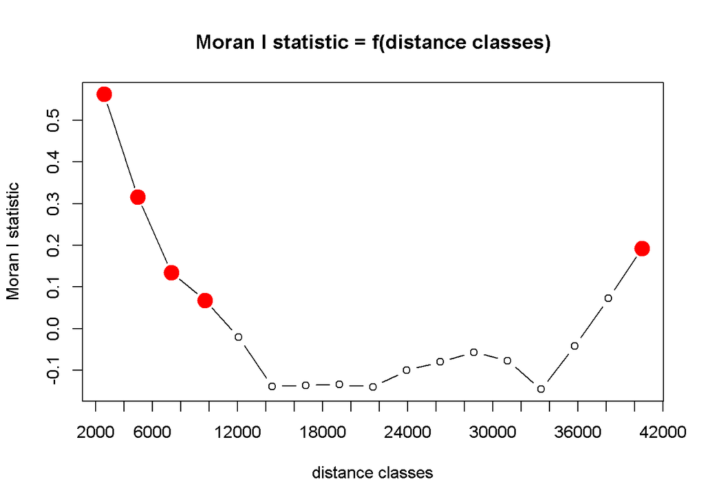

```r
plot(sp.cor2)
```

The `correlog` function selects automatically the higher distance limit, ca 40 km in this case. Unfortunately, this cannot be changed. We can, however, change the number of distance classes distributed regularly over this range.

-> Try to set `nbclass` parameter in the `correlog` function.

### Variogram

In geostatistics, the autocorrelation structure is typically described using the so called variogram instead of correlogram. (Note that what is commonly called variogram should be in fact called semivariogram. The general practice, however, does not distinguish between these two, although in the technical texts this could cause confusion. We follow the general practice here.)

(Semi)Variogram is defined as (half of) the variance of the differences between the variable values at arbitrary two locations separated by a certain distance. For a given distance, the higher this variance is, the less dependent these values are, et vice versa. This means that the interpretation of variogram is actually exactly opposite from the interpretation of the correlogram.

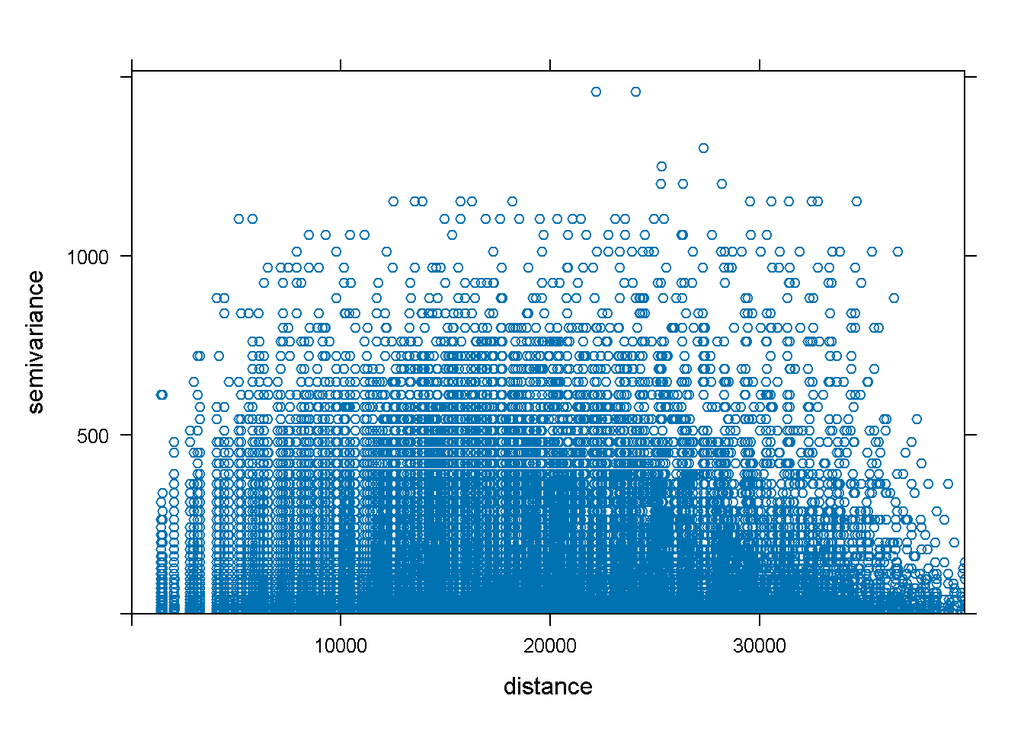

```r
variogram(richness~1, data = krnap, cutoff = 40000, cloud=T) %>% plot
```

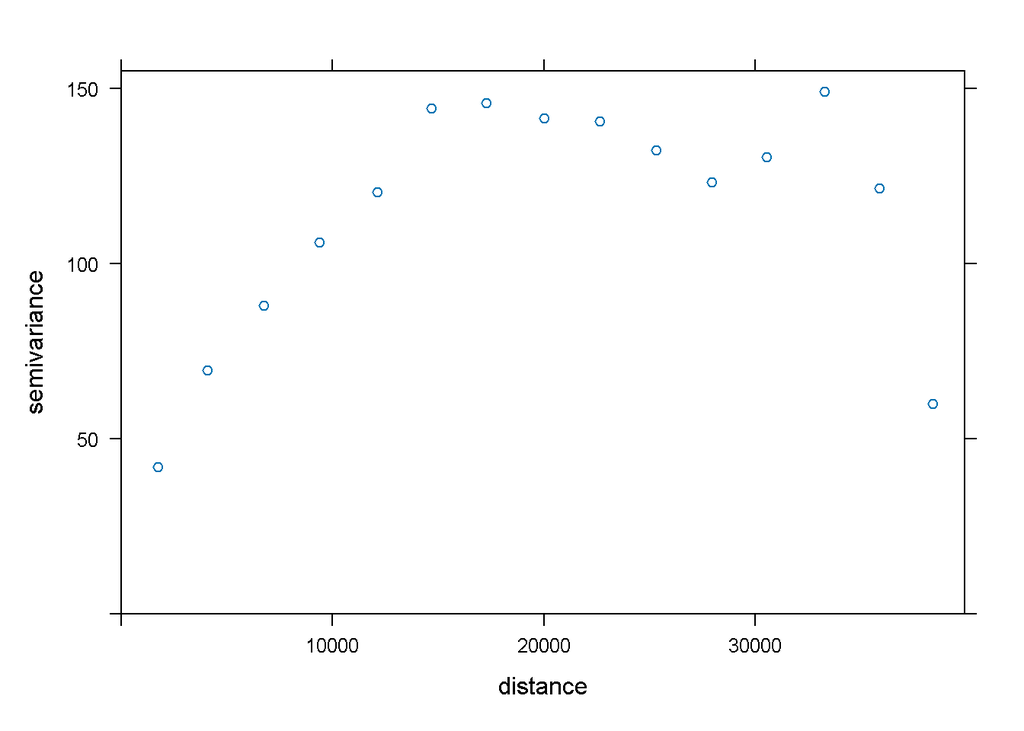

```r
vario <- variogram(richness~1, cutoff = 40000, data = krnap)
plot(vario)
```

```r
covario <- variogram(richness~1, data = krnap, cutoff=40000, covariogram=T)
tail(covario)
```

```
##      np     dist      gamma dir.hor dir.ver   id
## 11 2201 27940.71   1.493550       0       0 var1
## 12 1577 30539.49  -9.371605       0       0 var1
## 13  890 33249.87 -14.881987       0       0 var1
## 14  426 35856.45  -6.571221       0       0 var1
## 15  156 38363.60   4.842678       0       0 var1
## 16  348     0.00 119.128881       0       0 var1
```

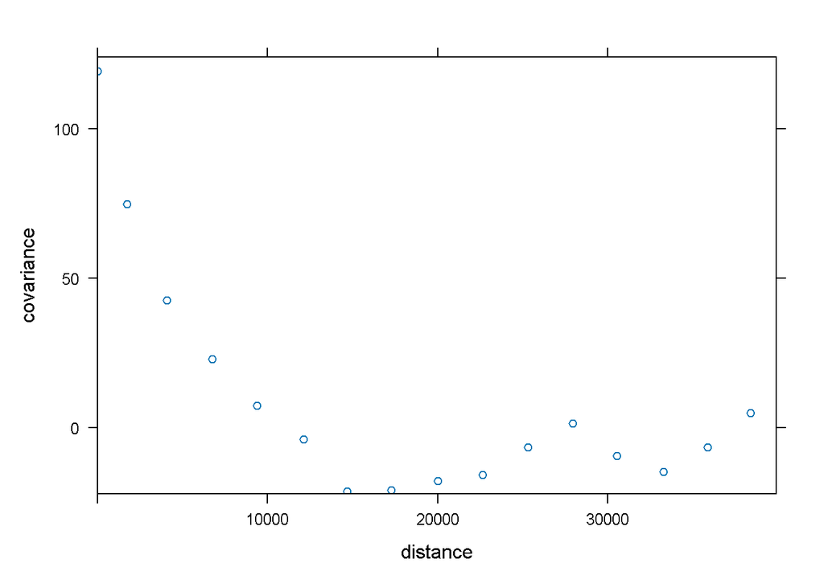

```r
plot(covario)
```

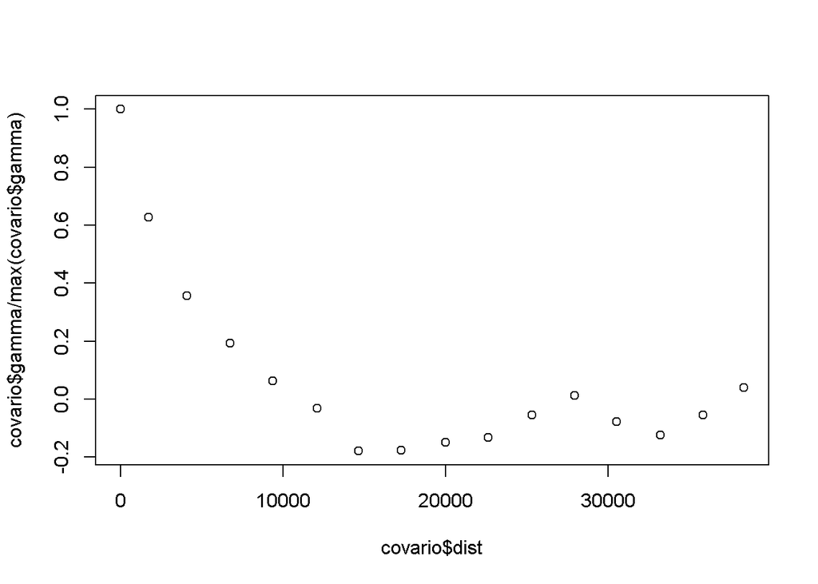

```r
plot(covario$dist, covario$gamma/max(covario$gamma))
```

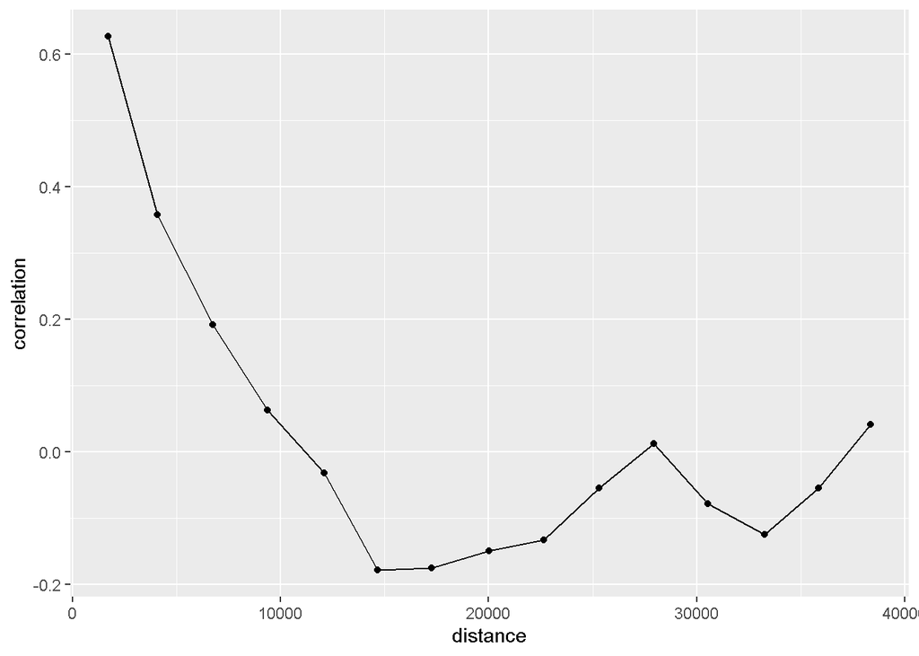

```r
data.frame(distance = covario$dist, correlation = covario$gamma/max(covario$gamma)) %>%
  arrange(desc(correlation)) %>%
  "["(2:nrow(.),) %>%
  ggplot(aes(x=distance, y=correlation)) +
  geom_line() +
  geom_point()
```

## Residual autocorrelation

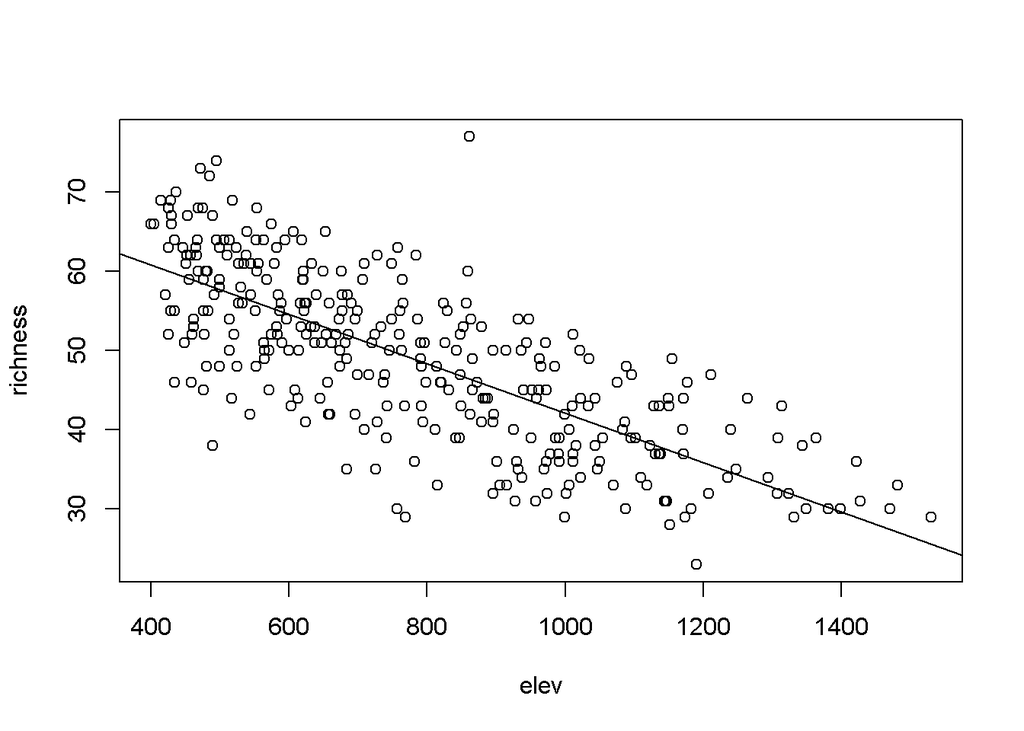

```r
krnap$elev <- st_extract(dtm, krnap) %>% pull(1)
plot(richness~elev, krnap)
abline(lm(richness~elev, krnap))
```

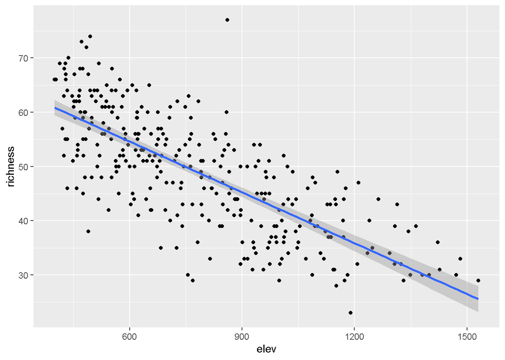

```r
ggplot(krnap, aes(x=elev, y=richness)) +
  geom_point() +
  geom_smooth(method="lm", se=T)
```

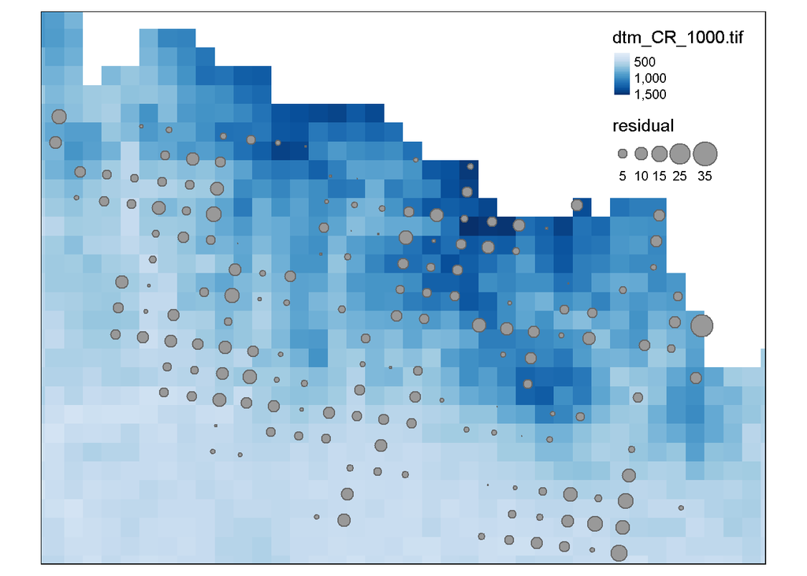

```r
krnap$residual[!is.na(krnap$elev)] <- lm(richness~elev, krnap)$residuals
tm_shape(dtm) +
  tm_raster(style="cont", palette="Blues") +
  tm_shape(krnap, is.master = T) +
  tm_bubbles("residual")
```

```r
krnap.subset <- na.omit(krnap)
neibs.res <- dnearneigh(st_coordinates(krnap.subset), d1=1000, d2=2000)
weights.res <- nb2listw(neibs.res, style="B")
```

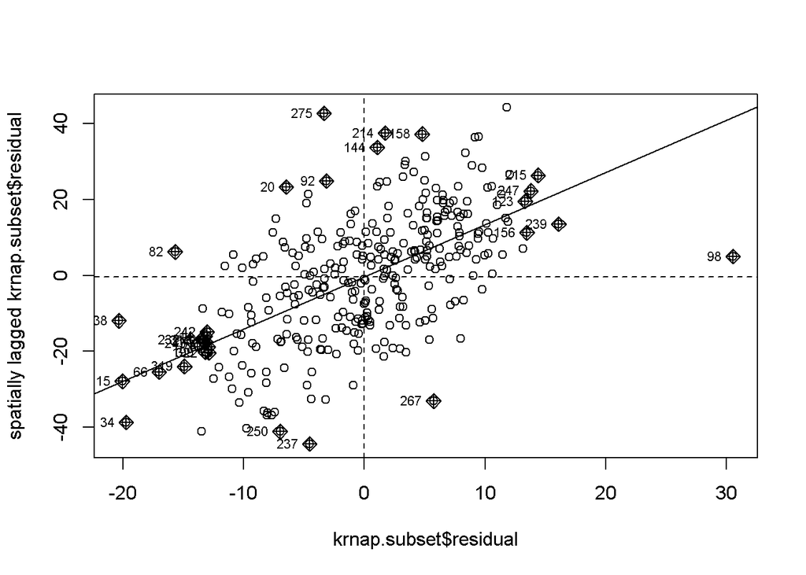

```r
moran.plot(krnap.subset$residual, weights.res)
```

```r
model <- lm(richness~elev, krnap.subset)
lm.morantest(model, weights.res)
```

```
##
##  Global Moran I for regression residuals
##
## data:
## model: lm(formula = richness ~ elev, data = krnap.subset)
## weights: weights.res
##
## Moran I statistic standard deviate = 9.304, p-value < 2.2e-16
## alternative hypothesis: greater
## sample estimates:
## Observed Moran I      Expectation         Variance
##      0.371313026     -0.005665489      0.001641699
```

```r
lm.morantest.exact(model, weights.res)
```

```
##
##  Global Moran I statistic with exact p-value
##
## data:
## model:lm(formula = richness ~ elev, data = krnap.subset)
## weights: weights.res
##
## Exact standard deviate = 6.642, p-value = 1.547e-11
## alternative hypothesis: greater
## sample estimates:
## [1] 0.371313
```

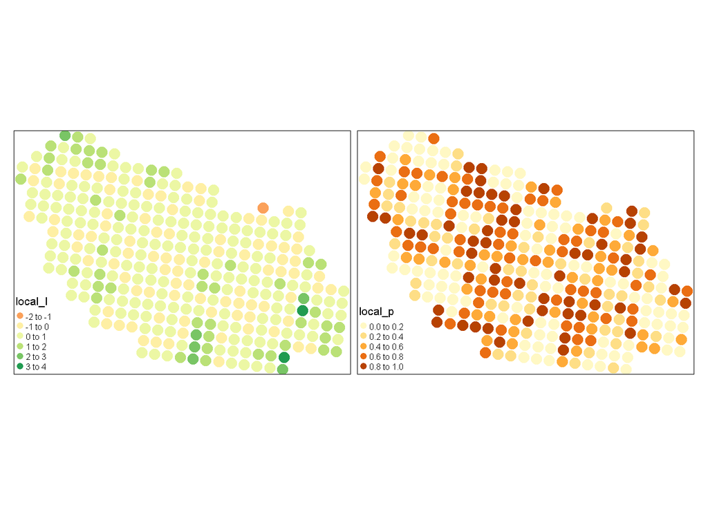

```r
loc.mor.res <- localmoran.exact(model=model, nb=neibs.res)
krnap.subset$local_I <- sapply(loc.mor.res, function(x) x$estimate)
krnap.subset$local_p <- sapply(loc.mor.res, function(x) x$p.value)
tm_shape(krnap.subset) +
  tm_dots(c("local_I", "local_p"), size=1) +
  tm_layout(legend.position = c("LEFT","BOTTOM"))
```

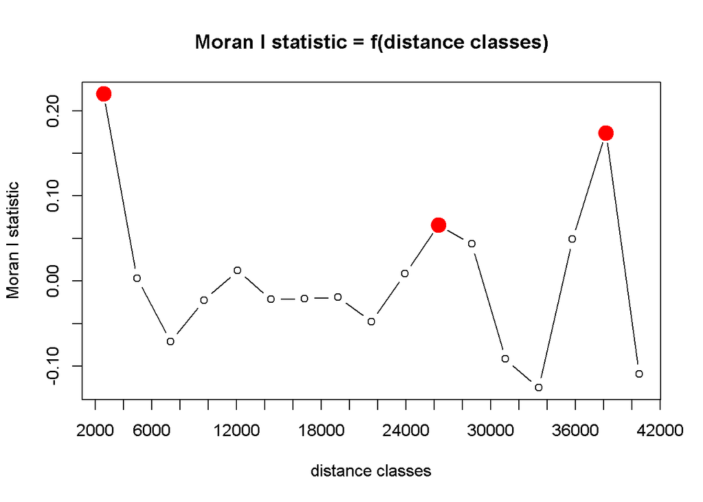

```r
correlog(st_coordinates(krnap.subset), krnap.subset$residual, method = "Moran") %>% plot
```

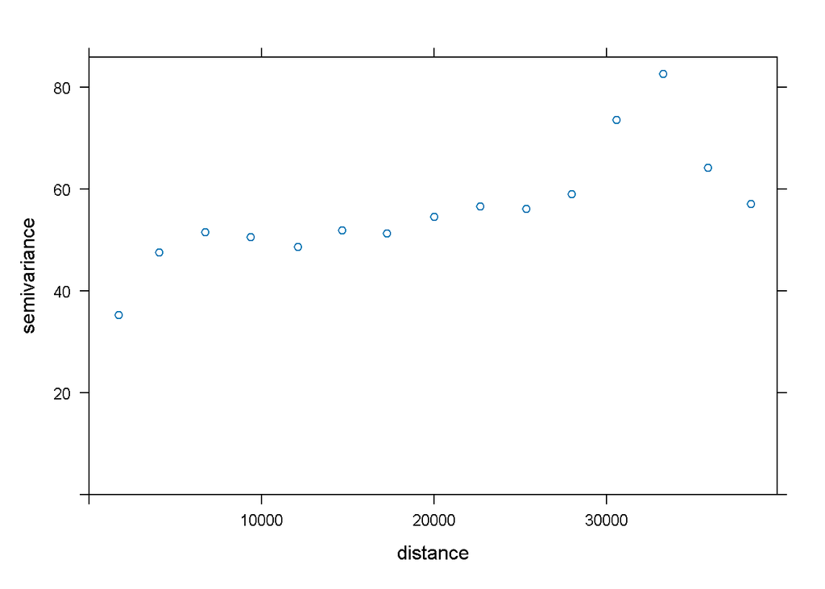

```r
variogram(richness~elev, data=krnap.subset, cutoff = 40000) %>% plot
```